# Take-Home Final Project

Computation for Data Analysis

Monday, 6 May 2019

Name: Ayaan Hussain Andrew ID: ayaanh

# Instructions

- You must work alone.
- Submit your knitted HTML or pdf file to Canvas by **Monday morning, 13 May 2019 by 11:30 am**
- For full credit on each question, make sure you follow exactly what is asked and answer each prompt. The total is 100 points.
- You may only ask clarification questions on Piazza; you may not ask for help unless you have problems loading data files. This is final project not a lab.
- Do not cheat. It will end poorly for everyone.

# Prostate cancer data set

Let’s return to the prostate cancer data set that we looked at in Week 3 (taken from the book [The Elements of Statistical Learning](http://statweb.stanford.edu/~hastie/ElemStatLearn/)). Recall, there are 9 variables measured on these 97 men:

1. `lcavol`: log cancer volume
2. `lweight`: log prostate weight
3. `age`: age of patient
4. `lbph`: log of the amount of benign prostatic hyperplasia
5. `svi`: seminal vesicle invasion
6. `lcp`: log of capsular penetration
7. `gleason`: Gleason score
8. `pgg45`: percent of Gleason scores 4 or 5
9. `lpsa`: log PSA score

Download the `pros_dat.txt` file from the Week 3 of the course canvas website. The following loads the data set into your R session, and stores it as a data frame `pros.dat`:

```r
pros.dat = read.table("pros_dat.txt")
```

**1a (3 pts)** Display its dimensions and the first 3 rows. Then display all the column names except for column 5. Finally display the column name for column 5.

```r
dim(pros.dat)
```

```
## [1] 97  9
```

```r
pros.dat[1:3,]
```

```
##       lcavol  lweight age      lbph svi       lcp gleason pgg45       lpsa
## 1 -0.5798185 2.769459  50 -1.386294   0 -1.386294       6     0 -0.4307829
## 2 -0.9942523 3.319626  58 -1.386294   0 -1.386294       6     0 -0.1625189
## 3 -0.5108256 2.691243  74 -1.386294   0 -1.386294       7    20 -0.1625189
```

```r
names(pros.dat[,-5])
```

```
## [1] "lcavol"  "lweight" "age"     "lbph"    "lcp"     "gleason" "pgg45"
## [8] "lpsa"
```

```r
colnames(pros.dat)[5]
```

```
## [1] "svi"
```

**1b (3 pts)** Calculate the mean of each variable. Also, calculate the standard deviation of each variable. Each should require just one line of code. Display your results.

```r
colMeans(pros.dat)
```

```
##     lcavol    lweight        age       lbph        svi        lcp
##  1.3500096  3.6289427 63.8659794  0.1003556  0.2164948 -0.1793656
##    gleason      pgg45       lpsa
##  6.7525773 24.3814433  2.4783869
```

```r
apply(pros.dat, FUN=sd,MARGIN = 2)
```

```
##     lcavol    lweight        age       lbph        svi        lcp
##  1.1786249  0.4284112  7.4451171  1.4508066  0.4139949  1.3982496
##    gleason      pgg45       lpsa
##  0.7221341 28.2040346  1.1543291
```

**1c (6 pts)** Now plot each variable against SVI. Using a loop, plot each variable, excluding SVI, on the y-axis with SVI on the x-axis. Label the x-axis and y-axis in your plots appropriately. For full credit, use column names not numerical indices in your code.

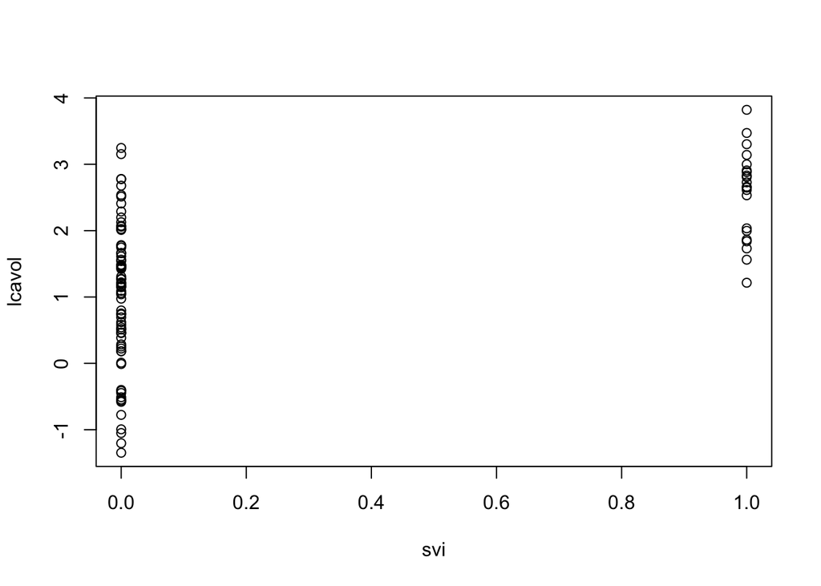

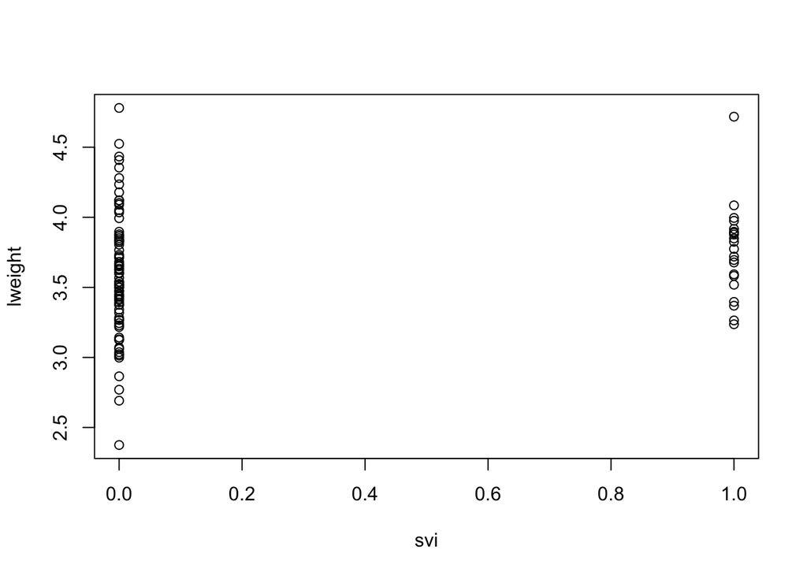

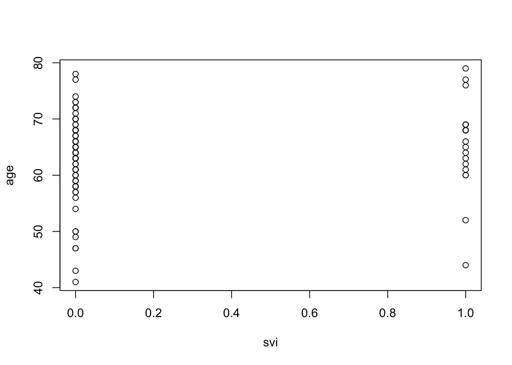

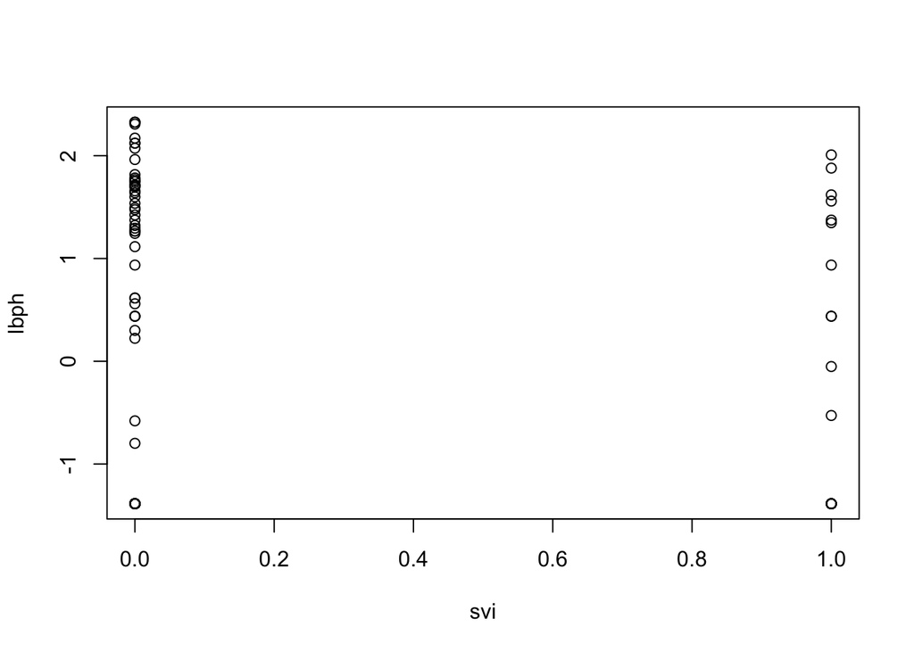

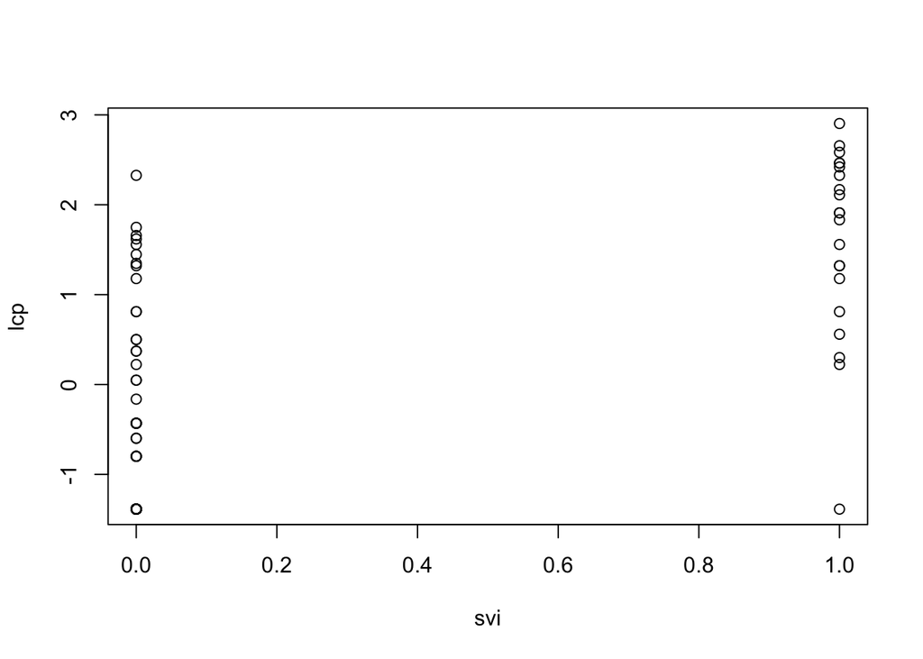

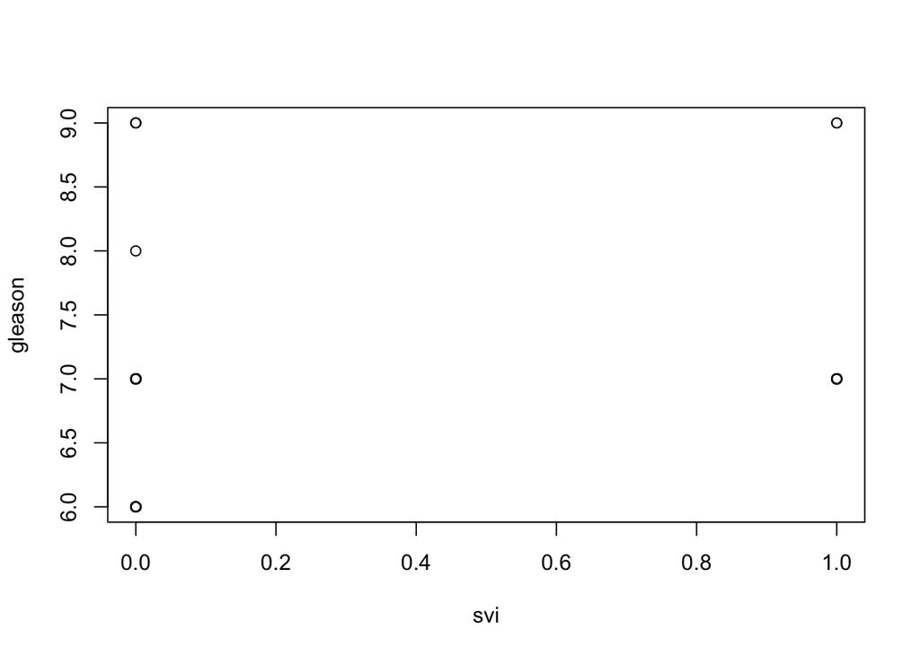

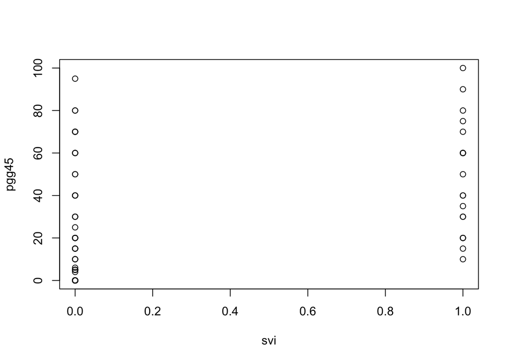

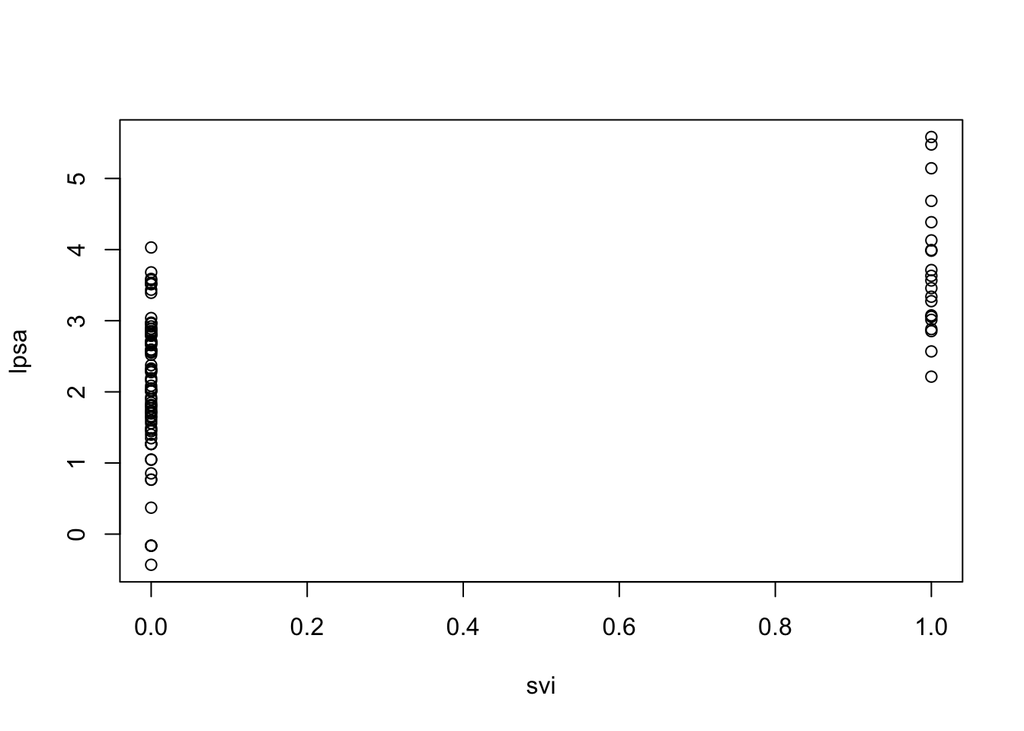

```r
for(i in 1:ncol(pros.dat))
{

  if(i!=5){
    plot(pros.dat$svi,pros.dat[,i],ylab =names(pros.dat)[i],xlab = "svi")
  }
}
```

**1d (10 pts)** Create a pair of overlapping histogram density plots of the `lcavol` variable for the SVI (value 1) and non-SVI (value 0) groups. Use 20 bars over the full range of `lcavol` values. Color the two groups of bars two different colors, one of them a transparent color. Add an estimated density line for each group. Provide labels and a legend as appropriate.

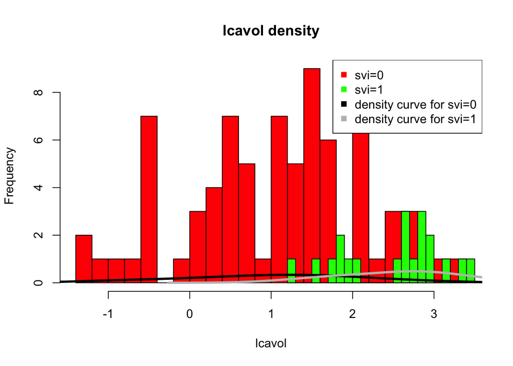

```r
hist(pros.dat$lcavol[which(pros.dat$svi==0)],breaks = 20,col="red",main="lcavol density",xlab="lcavol")
hist(pros.dat$lcavol[which(pros.dat$svi==1)],add=TRUE,col="green",breaks=20)
dens1=density(pros.dat$lcavol[which(pros.dat$svi==1)],adjust=1.5)
dens0=density(pros.dat$lcavol[which(pros.dat$svi==0)],adjust=1.5)
lines(dens0,lwd=3,col="black")
lines(dens1,lwd=3,col="grey")
legend("topright", col=c("red","green","black","grey"),legend=c("svi=0","svi=1","density curve for svi=0","density curve for svi=1"),pch=c(15,15))
```

**1e (5 pts)** Now, use `lapply()` to perform t-tests for each variable in the data set, between SVI and non-SVI groups. To be precise, you will perform a t-test for each variable excluding the SVI variable itself. For convenience, we’ve defined a function `t.test.by.ind()` below, which takes a numeric variable `x`, and then an indicator variable `ind` (of 0s and 1s) that defines the groups. Run this function on the columns of `pros.dat`, excluding the SVI column itself, and save the result as `tests`. Determine what kind of data structure `tests` is, and print it to the console.

```r
t.test.by.ind = function(x, ind) {
  stopifnot(all(ind %in% c(0, 1)))
  return(t.test(x[ind == 0], x[ind == 1]))
}

tests=lapply(pros.dat[,-5],ind=pros.dat$svi, FUN=t.test.by.ind)
typeof(tests)
```

```
## [1] "list"
```

**1f (6 pts)** Take a look at the first element of the `tests` object you created in the last question. Display to the console what kind of object is it, and extract and display its p-value. Using what you have learned, extract the p-values from `tests`. Use an apply function, in a single line of code.

```r
tests[1]
```

```
## $lcavol
##
##  Welch Two Sample t-test
##
## data:  x[ind == 0] and x[ind == 1]
## t = -8.0351, df = 51.172, p-value = 1.251e-10
## alternative hypothesis: true difference in means is not equal to 0
## 95 percent confidence interval:
##  -1.917326 -1.150810
## sample estimates:
## mean of x mean of y
##  1.017892  2.551959
```

```r
a=unlist(tests[1])
typeof(a)
```

```
## [1] "character"
```

```r
a["lcavol.p.value"]
```

```
##         lcavol.p.value
## "1.25103955694237e-10"
```

```r
lapply(tests,FUN=function(x){
  a=unlist(x)
  return(a[names(a)[3]])
})
```

```
## $lcavol
##                p.value
## "1.25103955694237e-10"
##
## $lweight
##              p.value
## "0.0747208752316629"
##
## $age
##             p.value
## "0.277053251131342"
##
## $lbph
##            p.value
## "0.38347718474222"
##
## $lcp
##                p.value
## "4.57975218962151e-10"
##
## $gleason
##                p.value
## "0.000881629334396299"
##
## $pgg45
##                p.value
## "2.48225499768971e-05"
##
## $lpsa
##                p.value
## "7.87906616729518e-08"
```

# Rio Olympics data set

Now we’re going to examine data from the 2016 Summer Olympics in Rio de Janeiro, taken from https://github.com/flother/rio2016 (itself put together by scraping the official Summer Olympics website for information about the athletes). Download the `rio.csv` file from the Finale module on the course website. The following reads in the data and stores it as `rio`.

**Note that all nonnumeric columns are factor variables**. Recall that factors are stored internally as integers. If `x` is a factor variable, you can get the level names for each `x` using `levels(x)`.

```r
rio = read.csv("rio.csv")
```

**2a (4 pts)** What kind of object is `rio`. Display its dimensions and columns names. What does each row represent? Determine if there is any missing data? If there is, how many rows contain missing data?

```r
typeof(rio)
```

```
## [1] "list"
```

```r
dim(rio)
```

```
## [1] 11538    12
```

```r
colnames(rio)
```

```
##  [1] "id"            "name"          "nationality"   "sex"
##  [5] "date_of_birth" "height"        "weight"        "sport"
##  [9] "gold"          "silver"        "bronze"        "info"
```

```r
a=complete.cases(rio)
length(a[a==FALSE])
```

```
## [1] 680
```

```
each row represents a different athlete
there are 680 rows with missing data
```

**2b (6 pts)** Use `rio` to answer the following questions. Write a sentence to the console for each answer. How many athletes competed in the 2016 Summer Olympics? How many countries were represented? What were these countries, and how many athletes competed for each one? Which country brought the most athletes, and how many was this?

```r
#number of athletes
print(nrow(rio))
```

```
## [1] 11538
```

```r
#number of countries
length(unique(rio$nationality))
```

```
## [1] 207
```

```r
#countries were
(a=levels(unique(rio$nationality)))
```

```
##   [1] "AFG" "ALB" "ALG" "AND" "ANG" "ANT" "ARG" "ARM" "ARU" "ASA" "AUS"
##  [12] "AUT" "AZE" "BAH" "BAN" "BAR" "BDI" "BEL" "BEN" "BER" "BHU" "BIH"
##  [23] "BIZ" "BLR" "BOL" "BOT" "BRA" "BRN" "BRU" "BUL" "BUR" "CAF" "CAM"
##  [34] "CAN" "CAY" "CGO" "CHA" "CHI" "CHN" "CIV" "CMR" "COD" "COK" "COL"
##  [45] "COM" "CPV" "CRC" "CRO" "CUB" "CYP" "CZE" "DEN" "DJI" "DMA" "DOM"
##  [56] "ECU" "EGY" "ERI" "ESA" "ESP" "EST" "ETH" "FIJ" "FIN" "FRA" "FSM"
##  [67] "GAB" "GAM" "GBR" "GBS" "GEO" "GEQ" "GER" "GHA" "GRE" "GRN" "GUA"
##  [78] "GUI" "GUM" "GUY" "HAI" "HKG" "HON" "HUN" "INA" "IND" "IOA" "IRI"
##  [89] "IRL" "IRQ" "ISL" "ISR" "ISV" "ITA" "IVB" "JAM" "JOR" "JPN" "KAZ"
## [100] "KEN" "KGZ" "KIR" "KOR" "KOS" "KSA" "LAO" "LAT" "LBA" "LBR" "LCA"
## [111] "LES" "LIB" "LIE" "LTU" "LUX" "MAD" "MAR" "MAS" "MAW" "MDA" "MDV"
## [122] "MEX" "MGL" "MHL" "MKD" "MLI" "MLT" "MNE" "MON" "MOZ" "MRI" "MTN"
## [133] "MYA" "NAM" "NCA" "NED" "NEP" "NGR" "NIG" "NOR" "NRU" "NZL" "OMA"
## [144] "PAK" "PAN" "PAR" "PER" "PHI" "PLE" "PLW" "PNG" "POL" "POR" "PRK"
## [155] "PUR" "QAT" "ROT" "ROU" "RSA" "RUS" "RWA" "SAM" "SEN" "SEY" "SIN"
## [166] "SKN" "SLE" "SLO" "SMR" "SOL" "SOM" "SRB" "SRI" "SSD" "STP" "SUD"
## [177] "SUI" "SUR" "SVK" "SWE" "SWZ" "SYR" "TAN" "TGA" "THA" "TJK" "TKM"
## [188] "TLS" "TOG" "TPE" "TTO" "TUN" "TUR" "TUV" "UAE" "UGA" "UKR" "URU"
## [199] "USA" "UZB" "VAN" "VEN" "VIE" "VIN" "YEM" "ZAM" "ZIM"
```

```r
b=vector()
for(n in 1:length(a)){
  b[a[n]]=length(which(rio$nationality==a[n]))
}
b
```

```
## AFG ALB ALG AND ANG ANT ARG ARM ARU ASA AUS AUT AZE BAH BAN BAR BDI BEL
##   3   6  68   5  26   9 223  32   7   4 431  71  56  30   7  11   9 108
## BEN BER BHU BIH BIZ BLR BOL BOT BRA BRN BRU BUL BUR CAF CAM CAN CAY CGO
##   6   8   2  11   3 124  12  12 485  34   3  50   5   6   6 321   5  10
## CHA CHI CHN CIV CMR COD COK COL COM CPV CRC CRO CUB CYP CZE DEN DJI DMA
##   2  42 404  12  24   4   9 154   4   5  11  88 123  16 104 128   7   2
## DOM ECU EGY ERI ESA ESP EST ETH FIJ FIN FRA FSM GAB GAM GBR GBS GEO GEQ
##  29  38 122  12   8 313  46  38  54  54 410   5   6   4 374   5  40   2
## GER GHA GRE GRN GUA GUI GUM GUY HAI HKG HON HUN INA IND IOA IRI IRL IRQ
## 441  16  93   7  21   5   5   6  10  38  30 154  28 123   9  64  80  26
## ISL ISR ISV ITA IVB JAM JOR JPN KAZ KEN KGZ KIR KOR KOS KSA LAO LAT LBA
##   8  47   7 312   4  57   8 346 103  80  19   3 213   8  11   6  32   7
## LBR LCA LES LIB LIE LTU LUX MAD MAR MAS MAW MDA MDV MEX MGL MHL MKD MLI
##   2   5   8   9   3  67  10   6  49  32   5  23   4 126  43   5   6   6
## MLT MNE MON MOZ MRI MTN MYA NAM NCA NED NEP NGR NIG NOR NRU NZL OMA PAK
##   7  35   3   6  11   2   7  10   5 249   7  78   6  62   2 208   4   7
## PAN PAR PER PHI PLE PLW PNG POL POR PRK PUR QAT ROT ROU RSA RUS RWA SAM
##  10  11  29  13   6   5   8 242  95  31  40  39  10  98 146 286   7   8
## SEN SEY SIN SKN SLE SLO SMR SOL SOM SRB SRI SSD STP SUD SUI SUR SVK SWE
##  22  10  25   7   4  63   5   3   2 103   9   3   3   6 104   6  51 164
## SWZ SYR TAN TGA THA TJK TKM TLS TOG TPE TTO TUN TUR TUV UAE UGA UKR URU
##   2   7   7   7  54   7   9   3   5  56  32  61 103   1  13  21 205  17
## USA UZB VAN VEN VIE VIN YEM ZAM ZIM
## 567  70   4  88  23   4   3   7  35
```

```r
sort(b,decreasing = TRUE)[1]
```

```
## USA
## 567
```

**2c (2 pts)** In a sentence, display an answer to the following question. How many medals of each type—gold, silver, bronze—were awarded at this Olympics?

```r
c(sum(rio$gold),sum(rio$silver),sum(rio$bronze))
```

```
## [1] 666 655 704
```

**2d (5 pts)** Create a column called `total` that adds the number of gold, silver, and bronze medals for each athlete, and add this column to `rio`. Which athlete had the most number of medals and how many was this? Gold medals? Silver medals? In the case of ties, here, display all the relevant athletes.

```r
total=as.integer(rowSums(rio[,9:11]))
rio=cbind(rio,total)
rio=rio[order(rio$total,decreasing = TRUE),]
rio[1,]$name
```

```
## [1] Michael Phelps
## 11517 Levels: A Jesus Garcia A Lam Shin Aaron Brown Aaron Cook ... Zuzana Hejnova
```

```r
rio[1,]$total
```

```
## [1] 6
```

```r
rio=rio[order(rio$gold,decreasing = TRUE),]
rio[1,]$name
```

```
## [1] Michael Phelps
## 11517 Levels: A Jesus Garcia A Lam Shin Aaron Brown Aaron Cook ... Zuzana Hejnova
```

```r
rio[1,]$gold
```

```
## [1] 5
```

```r
rio=rio[order(rio$silver,decreasing = TRUE),]
rio[which(rio$silver==2),]$name
```

```
##  [1] Simone Manuel               Emma McKeon
##  [3] Alexandra Raisman           Denis Abliazin
##  [5] Isaquias Queiroz dos Santos Chad Guy Bertrand le Clos
##  [7] Danell Leyva                Duncan Scott
##  [9] Florent Manaudou            Franziska Weber
## [11] James Guy                   Jazz Carlin
## [13] Madeline Groves             Maria Paseka
## [15] Rebecca James               Sarah Hammer
## [17] Taoufik Makhloufi           Tina Dietze
## [19] Wenyan Sun                  Xuechen Huang
## [21] Yulia Efimova
## 11517 Levels: A Jesus Garcia A Lam Shin Aaron Brown Aaron Cook ... Zuzana Hejnova
```

**2e (5 pts)** Using `tapply()`, calculate the total medal count for each country. Save the result as `total.by.nat`, and print it to the console. For each of the following questions, print a statement that states the answer. Which country had the most number of medals, and how many was this? How many countries had zero medals?

```r
total.by.nat=tapply(rio$total,FUN=sum,INDEX = rio$nationality)
total.by.nat
```

```
## AFG ALB ALG AND ANG ANT ARG ARM ARU ASA AUS AUT AZE BAH BAN BAR BDI BEL
##   0   0   2   0   0   0  22   4   0   0  82   2  18   6   0   0   1  21
## BEN BER BHU BIH BIZ BLR BOL BOT BRA BRN BRU BUL BUR CAF CAM CAN CAY CGO
##   0   0   0   0   0  12   0   0  51   2   0   7   0   0   0  69   0   0
## CHA CHI CHN CIV CMR COD COK COL COM CPV CRC CRO CUB CYP CZE DEN DJI DMA
##   0   0 113   2   0   0   0   8   0   0   0  24  11   0  15  41   0   0
## DOM ECU EGY ERI ESA ESP EST ETH FIJ FIN FRA FSM GAB GAM GBR GBS GEO GEQ
##   1   0   3   0   0  45   4   8  13   1  95   0   0   0 145   0   7   0
## GER GHA GRE GRN GUA GUI GUM GUY HAI HKG HON HUN INA IND IOA IRI IRL IRQ
## 160   0   7   1   0   0   0   0   0   0   0  22   4   2   2   8   3   0
## ISL ISR ISV ITA IVB JAM JOR JPN KAZ KEN KGZ KIR KOR KOS KSA LAO LAT LBA
##   0   2   0  72   0  30   1  65  17  13   0   0  26   1   0   0   0   0
## LBR LCA LES LIB LIE LTU LUX MAD MAR MAS MAW MDA MDV MEX MGL MHL MKD MLI
##   0   0   0   0   0   7   0   0   1   8   0   1   0   5   2   0   0   0
## MLT MNE MON MOZ MRI MTN MYA NAM NCA NED NEP NGR NIG NOR NRU NZL OMA PAK
##   0   0   0   0   0   0   0   0   0  47   0  18   1  19   0  36   0   0
## PAN PAR PER PHI PLE PLW PNG POL POR PRK PUR QAT ROT ROU RSA RUS RWA SAM
##   0   0   0   1   0   0   0  16   1   7   1   1   0  17  23 115   0   0
## SEN SEY SIN SKN SLE SLO SMR SOL SOM SRB SRI SSD STP SUD SUI SUR SVK SWE
##   0   0   1   0   0   4   0   0   0  53   0   0   0   0  11   0   8  28
## SWZ SYR TAN TGA THA TJK TKM TLS TOG TPE TTO TUN TUR TUV UAE UGA UKR URU
##   0   0   0   0   6   1   0   0   0   5   1   3   8   0   1   0  15   0
## USA UZB VAN VEN VIE VIN YEM ZAM ZIM
## 264  13   0   3   2   0   0   0   0
```

```r
sort(total.by.nat,decreasing = TRUE)[1]
```

```
## USA
## 264
```

```r
length(total.by.nat[which(total.by.nat==0)])
```

```
## [1] 120
```

**2f (5 pts)** Among the countries that had zero medals, which had the most athletes, and how many athletes was this?

```r
c=names(total.by.nat[which(total.by.nat==0)])
b=vector()
for(n in 1:length(c)){
  b[c[n]]=length(which(rio$nationality==c[n]))
}
b=sort(b,decreasing = TRUE)
b[1]
```

```
## CHI
##  42
```

# Young and old by sport

**3a (6 pts)** The variable `date_of_birth` contains strings of the date of birth of each athlete. Use text processing commands to extract the year of birth, and create a new numeric variable called `age`, equal to 2016 - (the year of birth). (Here we’re ignoring days and months for simplicity.) Add the `age` variable to the `rio` data frame. Who is the oldest athlete, and how old is he/she? Youngest athlete, and how old is he/she? In the case of ties, here, display all the relevant athletes.

```r
age=strtoi(substr(rio$date_of_birth,1,4))
age=2016-age
rio=cbind(rio,age)
rio=rio[order(rio$age,decreasing = TRUE),]
rio[1,]$age
```

```
## [1] 62
```

```r
rio[which(rio$age==62),]$name
```

```
## [1] Julie Brougham Mary Hanna
## 11517 Levels: A Jesus Garcia A Lam Shin Aaron Brown Aaron Cook ... Zuzana Hejnova
```

```r
rio[nrow(rio),]$age
```

```
## [1] 14
```

```r
rio[which(rio$age==14),]$name
```

```
## [1] Ana Iulia Dascal     Darya Semyonova      Fatima Alkaramova
## [4] Gaurika Singh        Kaya Adwoa Forson    Siri Arun Budcharern
## [7] Thint Myaat          Yanhan Ai
## 11517 Levels: A Jesus Garcia A Lam Shin Aaron Brown Aaron Cook ... Zuzana Hejnova
```

**3b (4 pts)** Answer the same questions as in the last part, but now only among athletes who won a medal.

```r
age=strtoi(substr(rio$date_of_birth,1,4))
age=2016-age
d=cbind(rio,age)
d=d[order(d$age,decreasing = TRUE),]
d=d[d$total >0,]
d[1,]$age
```

```
## [1] 59
```

```r
d[which(d$age==59),]$name
```

```
## [1] Nick Skelton
## 11517 Levels: A Jesus Garcia A Lam Shin Aaron Brown Aaron Cook ... Zuzana Hejnova
```

```r
d[nrow(d),]$age
```

```
## [1] 15
```

```r
d[which(d$age==15),]$name
```

```
## [1] Qian Ren
## 11517 Levels: A Jesus Garcia A Lam Shin Aaron Brown Aaron Cook ... Zuzana Hejnova
```

**3c (5 pts)** Using `split()` and `sapply()` find the number of participants in each sport and the number of gold medals given out for each sport.

```r
a=split(rio,f=rio$sport)
sapply(a, FUN=function(x){
  return(c(names(x$sport),"participants"=nrow(x),"gold"=sum(x$gold)))
})
```

```
##              aquatics archery athletics badminton basketball boxing canoe
## participants     1445     128      2363       172        288    286   331
## gold              120       8        66         8         24     13    27
##              cycling equestrian fencing football golf gymnastics handball
## participants     525        222     246      611  120        324      363
## gold              27         15      21       36    2         30       29
##              hockey judo modern pentathlon rowing rugby sevens sailing
## participants    432  392                72    547          300     380
## gold             34   14                 2     48           25      15
##              shooting table tennis taekwondo tennis triathlon volleyball
## participants      390          172       128    196       110        384
## gold               15            8         8      8         2         28
##              weightlifting wrestling
## participants           258       353
## gold                    15        18
```

**3d (5 pts)** How old are the youngest and oldest athletes for each sport? Your answer should be a matrix that has one row for each sport, and two columns that display the ages of the youngest and oldest athletes in that sport. The first 3 rows should look like this:

```
                  Youngest Oldest
aquatics               14     41
archery                17     44
athletics              16     47
```

```r
ret=matrix(nrow = length(a),ncol = 2,dimnames = list(names(a),c("Youngest","Oldest")))
for(i in 1:length(a)){
  ret[i,1]=min(a[[i]]$age)
  ret[i,2]=max(a[[i]]$age)
}
ret
```

```
##                   Youngest Oldest
## aquatics                14     41
## archery                 17     44
## athletics               16     47
## badminton               19     40
## basketball              20     39
## boxing                  18     37
## canoe                   18     49
## cycling                 18     45
## equestrian              18     62
## fencing                 16     42
## football                16     41
## golf                    18     47
## gymnastics              16     41
## handball                19     44
## hockey                  18     37
## judo                    19     39
## modern pentathlon       17     37
## rowing                  18     57
## rugby sevens            18     36
## sailing                 17     55
## shooting                16     56
## table tennis            15     54
## taekwondo               17     38
## tennis                  19     44
## triathlon               19     38
## volleyball              18     41
## weightlifting           16     41
## wrestling               18     38
```

# Text and functions

Now we will return to analyzing a text word file by writing two versions of a function to create a table of word frequencies. Download the `clinton.txt` file from Week 6 of the canvas website.

**4a (10 pts)** Create a function named `create_word_table()` that returns a table of words given the name of a text file as input. Your function should use `readLines()` to read the file, split the text at every single space into words (all lower case), remove empty words, and finally return a table of frequencies. Be sure to provide comments that describes your function and lists its inputs and output. Call your function on the `clinton.txt` word file and show the first 30 elements.

```r
create_word_table=function(name){
  #reading file from name
  raw=readLines(name)
  #unlisting vector removes null elements as well
  raw=unlist(strsplit(tolower(raw)," "))
  return(raw)
}
a=create_word_table("clinton.txt")
print(a[1:30])
```

```
##  [1] "thank"      "you!"       "thank"      "you"        "all"
##  [6] "very"       "much!"      "thank"      "you"        "for"
## [11] "that"       "amazing"    "welcome."   "thank"      "you"
## [16] "all"        "for"        "the"        "great"      "convention"
## [21] "that"       "we’ve"      "had."       "and"        "chelsea,"
## [26] "thank"      "you."       "i'm"        "so"         "proud"
```

**4b (10 pts)** Improve your function by adding `split` as an argument, with a default value that splits at white spaces and punctuation followed by white spaces. Add logical arguments with default values that indicate whether or not to sort the word table (sort in decreasing order) or whether or not to plot the sorted word table. The plot type should be a line and have labels as appropriate. Update your comments. Call your function on the `clinton.txt` word file with the sort and plot arguments set to true (which need not be your default values) and show the first 30 elements returned.

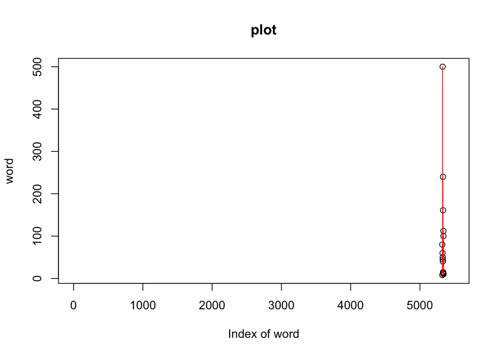

```r
create_word_table=function(name,split="[[:space:]]|[[:punct:]]+[[:space:]]",sort=FALSE,plot=FALSE){
  #reading file from name
  raw=readLines(name)
  #unlisting vector removes null elements as well
  raw=unlist(strsplit(tolower(raw),split))
  #sorting as needed
  if(sort==TRUE){
    raw=raw[order(raw,decreasing = sort)]
  }
  #plotting if needed
  if(plot==TRUE){
    plot(raw,xlab="Index of word",ylab="word")
    lines(raw,col="red")
    title(main="plot")
  }
  return(raw)
}
a=create_word_table("clinton.txt"," ",TRUE,TRUE)
```

```r
print(a[1:30])
```

```
##  [1] "zip"       "zero."     "zero"      "yourself:" "your"
##  [6] "your"      "your"      "your"      "your"      "your"
## [11] "your"      "your"      "your"      "your"      "your"
## [16] "your"      "your"      "your"      "your"      "your"
## [21] "your"      "your"      "your"      "your"      "your"
## [26] "young"     "young"     "young"     "young"     "young"
```